# Risk Factor Analysis

## Outcome Variable

**Outcome Variable:** ever_co

## Predictor Variables

**Intervention Variable:** hfoodsec

**Adjustment Set:**

- arm
- sex
- W_mage
- meducyrs
- feducyrs
- hhwealth_quart
- vagbrth
- W_nrooms
- W_nchldlt5
- brthmon
- W_parity
- impfloor
- impsan
- safeh20
- delta_W_mage
- delta_meducyrs
- delta_feducyrs
- delta_hhwealth_quart
- delta_vagbrth
- delta_W_nrooms
- delta_W_nchldlt5
- delta_brthmon
- delta_W_parity
- delta_impfloor
- delta_impsan
- delta_safeh20

## Stratifying Variables

The analysis was stratified on these variable(s):

- agecat
- studyid
- country

## Data Summary

| agecat | studyid | country | hfoodsec | ever_co | n_cell | n |
| --- | --- | --- | --- | --- | --- | --- |
| 0-24 months | ki0047075b-MAL-ED | BANGLADESH | Food Secure | 0 | 135 | 194 |
| 0-24 months | ki0047075b-MAL-ED | BANGLADESH | Food Secure | 1 | 26 | 194 |
| 0-24 months | ki0047075b-MAL-ED | BANGLADESH | Mildly Food Insecure | 0 | 3 | 194 |
| 0-24 months | ki0047075b-MAL-ED | BANGLADESH | Mildly Food Insecure | 1 | 1 | 194 |
| 0-24 months | ki0047075b-MAL-ED | BANGLADESH | Food Insecure | 0 | 24 | 194 |
| 0-24 months | ki0047075b-MAL-ED | BANGLADESH | Food Insecure | 1 | 5 | 194 |
| 0-24 months | ki0047075b-MAL-ED | BRAZIL | Food Secure | 0 | 3 | 129 |
| 0-24 months | ki0047075b-MAL-ED | BRAZIL | Food Secure | 1 | 0 | 129 |
| 0-24 months | ki0047075b-MAL-ED | BRAZIL | Mildly Food Insecure | 0 | 11 | 129 |
| 0-24 months | ki0047075b-MAL-ED | BRAZIL | Mildly Food Insecure | 1 | 0 | 129 |
| 0-24 months | ki0047075b-MAL-ED | BRAZIL | Food Insecure | 0 | 112 | 129 |
| 0-24 months | ki0047075b-MAL-ED | BRAZIL | Food Insecure | 1 | 3 | 129 |
| 0-24 months | ki0047075b-MAL-ED | INDIA | Food Secure | 0 | 143 | 212 |
| 0-24 months | ki0047075b-MAL-ED | INDIA | Food Secure | 1 | 47 | 212 |
| 0-24 months | ki0047075b-MAL-ED | INDIA | Mildly Food Insecure | 0 | 5 | 212 |
| 0-24 months | ki0047075b-MAL-ED | INDIA | Mildly Food Insecure | 1 | 0 | 212 |
| 0-24 months | ki0047075b-MAL-ED | INDIA | Food Insecure | 0 | 14 | 212 |
| 0-24 months | ki0047075b-MAL-ED | INDIA | Food Insecure | 1 | 3 | 212 |
| 0-24 months | ki0047075b-MAL-ED | NEPAL | Food Secure | 0 | 86 | 128 |
| 0-24 months | ki0047075b-MAL-ED | NEPAL | Food Secure | 1 | 8 | 128 |
| 0-24 months | ki0047075b-MAL-ED | NEPAL | Mildly Food Insecure | 0 | 13 | 128 |
| 0-24 months | ki0047075b-MAL-ED | NEPAL | Mildly Food Insecure | 1 | 2 | 128 |
| 0-24 months | ki0047075b-MAL-ED | NEPAL | Food Insecure | 0 | 13 | 128 |
| 0-24 months | ki0047075b-MAL-ED | NEPAL | Food Insecure | 1 | 6 | 128 |
| 0-24 months | ki0047075b-MAL-ED | PERU | Food Secure | 0 | 24 | 113 |
| 0-24 months | ki0047075b-MAL-ED | PERU | Food Secure | 1 | 3 | 113 |
| 0-24 months | ki0047075b-MAL-ED | PERU | Mildly Food Insecure | 0 | 29 | 113 |
| 0-24 months | ki0047075b-MAL-ED | PERU | Mildly Food Insecure | 1 | 0 | 113 |
| 0-24 months | ki0047075b-MAL-ED | PERU | Food Insecure | 0 | 53 | 113 |
| 0-24 months | ki0047075b-MAL-ED | PERU | Food Insecure | 1 | 4 | 113 |

[output cut: 168 more lines]

The following strata were considered:

- agecat: 0-24 months, studyid: ki0047075b-MAL-ED, country: BANGLADESH
- agecat: 0-24 months, studyid: ki0047075b-MAL-ED, country: BRAZIL
- agecat: 0-24 months, studyid: ki0047075b-MAL-ED, country: INDIA
- agecat: 0-24 months, studyid: ki0047075b-MAL-ED, country: NEPAL
- agecat: 0-24 months, studyid: ki0047075b-MAL-ED, country: PERU
- agecat: 0-24 months, studyid: ki0047075b-MAL-ED, country: SOUTH AFRICA
- agecat: 0-24 months, studyid: ki1017093-NIH-Birth, country: BANGLADESH
- agecat: 0-24 months, studyid: ki1017093c-NIH-Crypto, country: BANGLADESH
- agecat: 0-24 months, studyid: ki1113344-GMS-Nepal, country: NEPAL
- agecat: 0-24 months, studyid: kiGH5241-JiVitA-3, country: BANGLADESH
- agecat: 0-24 months, studyid: kiGH5241-JiVitA-4, country: BANGLADESH
- agecat: 0-6 months, studyid: ki0047075b-MAL-ED, country: BANGLADESH
- agecat: 0-6 months, studyid: ki0047075b-MAL-ED, country: BRAZIL
- agecat: 0-6 months, studyid: ki0047075b-MAL-ED, country: INDIA
- agecat: 0-6 months, studyid: ki0047075b-MAL-ED, country: NEPAL
- agecat: 0-6 months, studyid: ki0047075b-MAL-ED, country: PERU
- agecat: 0-6 months, studyid: ki0047075b-MAL-ED, country: SOUTH AFRICA
- agecat: 0-6 months, studyid: ki1017093-NIH-Birth, country: BANGLADESH
- agecat: 0-6 months, studyid: ki1017093c-NIH-Crypto, country: BANGLADESH
- agecat: 0-6 months, studyid: ki1113344-GMS-Nepal, country: NEPAL
- agecat: 0-6 months, studyid: kiGH5241-JiVitA-3, country: BANGLADESH
- agecat: 0-6 months, studyid: kiGH5241-JiVitA-4, country: BANGLADESH
- agecat: 6-24 months, studyid: ki0047075b-MAL-ED, country: BANGLADESH
- agecat: 6-24 months, studyid: ki0047075b-MAL-ED, country: BRAZIL
- agecat: 6-24 months, studyid: ki0047075b-MAL-ED, country: INDIA
- agecat: 6-24 months, studyid: ki0047075b-MAL-ED, country: NEPAL
- agecat: 6-24 months, studyid: ki0047075b-MAL-ED, country: PERU
- agecat: 6-24 months, studyid: ki0047075b-MAL-ED, country: SOUTH AFRICA
- agecat: 6-24 months, studyid: ki1017093-NIH-Birth, country: BANGLADESH
- agecat: 6-24 months, studyid: ki1017093c-NIH-Crypto, country: BANGLADESH
- agecat: 6-24 months, studyid: ki1113344-GMS-Nepal, country: NEPAL
- agecat: 6-24 months, studyid: kiGH5241-JiVitA-3, country: BANGLADESH
- agecat: 6-24 months, studyid: kiGH5241-JiVitA-4, country: BANGLADESH

### Dropped Strata

Some strata were dropped due to rare outcomes:

- agecat: 0-24 months, studyid: ki0047075b-MAL-ED, country: BANGLADESH
- agecat: 0-24 months, studyid: ki0047075b-MAL-ED, country: BRAZIL
- agecat: 0-24 months, studyid: ki0047075b-MAL-ED, country: INDIA
- agecat: 0-24 months, studyid: ki0047075b-MAL-ED, country: NEPAL
- agecat: 0-24 months, studyid: ki0047075b-MAL-ED, country: PERU
- agecat: 0-24 months, studyid: ki0047075b-MAL-ED, country: SOUTH AFRICA
- agecat: 0-6 months, studyid: ki0047075b-MAL-ED, country: BANGLADESH
- agecat: 0-6 months, studyid: ki0047075b-MAL-ED, country: BRAZIL
- agecat: 0-6 months, studyid: ki0047075b-MAL-ED, country: INDIA
- agecat: 0-6 months, studyid: ki0047075b-MAL-ED, country: NEPAL
- agecat: 0-6 months, studyid: ki0047075b-MAL-ED, country: PERU
- agecat: 0-6 months, studyid: ki0047075b-MAL-ED, country: SOUTH AFRICA
- agecat: 0-6 months, studyid: ki1017093-NIH-Birth, country: BANGLADESH
- agecat: 0-6 months, studyid: ki1017093c-NIH-Crypto, country: BANGLADESH
- agecat: 0-6 months, studyid: ki1113344-GMS-Nepal, country: NEPAL
- agecat: 6-24 months, studyid: ki0047075b-MAL-ED, country: BANGLADESH
- agecat: 6-24 months, studyid: ki0047075b-MAL-ED, country: BRAZIL
- agecat: 6-24 months, studyid: ki0047075b-MAL-ED, country: INDIA
- agecat: 6-24 months, studyid: ki0047075b-MAL-ED, country: NEPAL
- agecat: 6-24 months, studyid: ki0047075b-MAL-ED, country: PERU
- agecat: 6-24 months, studyid: ki0047075b-MAL-ED, country: SOUTH AFRICA

## Methods Detail

We’re interested in the causal parameters $E[Y_a]$ for all values of $a \in \mathcal{A}$. These parameters represent the mean outcome if, possibly contrary to fact, we intervened to set all units to have $A=a$. Under the randomization and positivity assumptions, these are identified by the statistical parameters $\psi_a=E_W[E_{Y|A,W}(Y|A=a,W)]$. In addition, we’re interested in the mean of $Y$, $E[Y]$ under no intervention (the observed mean). We will estimate these parameters by using SuperLearner to fit the relevant likelihood factors – $E_{Y|A,W}(Y|A=a,W)$ and $p(A=a|W)$, and then updating our likelihood fit using a joint TMLE.

For unadjusted analyses ($W=\{\}$), initial likelihoods were estimated using Lrnr_glm to estimate the simple $E(Y|A)$ and Lrnr_mean to estimate $p(A)$. For adjusted analyses, a small library containing Lrnr_glmnet, Lrnr_xgboost, and Lrnr_mean was used.

Having estimated these parameters, we will then use the delta method to estimate relative risks and attributable risks relative to a prespecified baseline level of $A$.

# Results Detail

## Results Plots

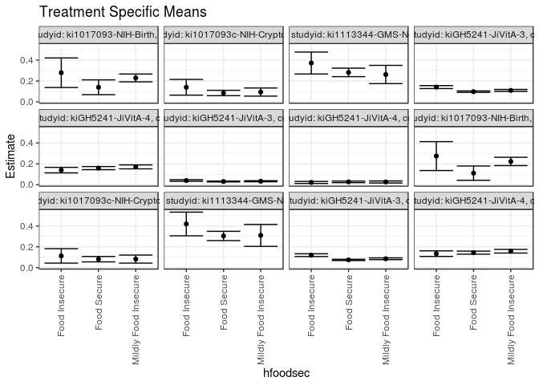

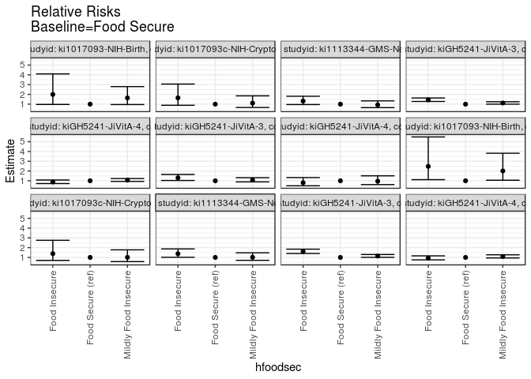

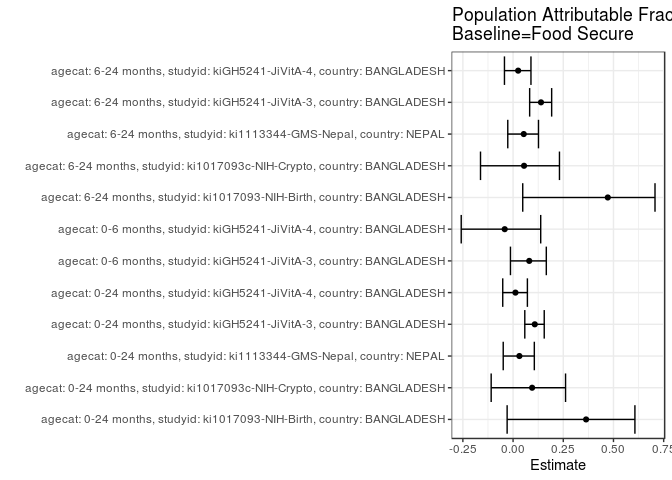

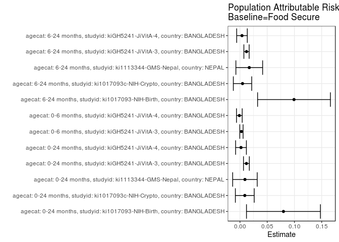

## Results Table

### Parameter: TSM

| agecat | studyid | country | intervention_level | baseline_level | estimate | ci_lower | ci_upper |
| --- | --- | --- | --- | --- | --- | --- | --- |
| 0-24 months | ki1017093-NIH-Birth | BANGLADESH | Food Secure | NA | 0.1396980 | 0.0686880 | 0.2107079 |
| 0-24 months | ki1017093-NIH-Birth | BANGLADESH | Mildly Food Insecure | NA | 0.2290747 | 0.1917194 | 0.2664300 |
| 0-24 months | ki1017093-NIH-Birth | BANGLADESH | Food Insecure | NA | 0.2788599 | 0.1371324 | 0.4205874 |
| 0-24 months | ki1017093c-NIH-Crypto | BANGLADESH | Food Secure | NA | 0.0847771 | 0.0589731 | 0.1105811 |
| 0-24 months | ki1017093c-NIH-Crypto | BANGLADESH | Mildly Food Insecure | NA | 0.0938020 | 0.0548567 | 0.1327472 |
| 0-24 months | ki1017093c-NIH-Crypto | BANGLADESH | Food Insecure | NA | 0.1395038 | 0.0643510 | 0.2146566 |
| 0-24 months | ki1113344-GMS-Nepal | NEPAL | Food Secure | NA | 0.2819372 | 0.2412977 | 0.3225767 |
| 0-24 months | ki1113344-GMS-Nepal | NEPAL | Mildly Food Insecure | NA | 0.2619633 | 0.1746046 | 0.3493220 |
| 0-24 months | ki1113344-GMS-Nepal | NEPAL | Food Insecure | NA | 0.3719829 | 0.2670625 | 0.4769034 |
| 0-24 months | kiGH5241-JiVitA-3 | BANGLADESH | Food Secure | NA | 0.0977996 | 0.0909523 | 0.1046469 |
| 0-24 months | kiGH5241-JiVitA-3 | BANGLADESH | Mildly Food Insecure | NA | 0.1093762 | 0.1001417 | 0.1186107 |
| 0-24 months | kiGH5241-JiVitA-3 | BANGLADESH | Food Insecure | NA | 0.1412054 | 0.1269660 | 0.1554448 |
| 0-24 months | kiGH5241-JiVitA-4 | BANGLADESH | Food Secure | NA | 0.1596300 | 0.1445720 | 0.1746880 |
| 0-24 months | kiGH5241-JiVitA-4 | BANGLADESH | Mildly Food Insecure | NA | 0.1713354 | 0.1525053 | 0.1901656 |
| 0-24 months | kiGH5241-JiVitA-4 | BANGLADESH | Food Insecure | NA | 0.1403538 | 0.1138739 | 0.1668336 |
| 0-6 months | kiGH5241-JiVitA-3 | BANGLADESH | Food Secure | NA | 0.0310557 | 0.0270464 | 0.0350649 |
| 0-6 months | kiGH5241-JiVitA-3 | BANGLADESH | Mildly Food Insecure | NA | 0.0336016 | 0.0284003 | 0.0388029 |
| 0-6 months | kiGH5241-JiVitA-3 | BANGLADESH | Food Insecure | NA | 0.0405072 | 0.0327966 | 0.0482177 |
| 0-6 months | kiGH5241-JiVitA-4 | BANGLADESH | Food Secure | NA | 0.0278187 | 0.0204855 | 0.0351520 |
| 0-6 months | kiGH5241-JiVitA-4 | BANGLADESH | Mildly Food Insecure | NA | 0.0267467 | 0.0169513 | 0.0365420 |
| 0-6 months | kiGH5241-JiVitA-4 | BANGLADESH | Food Insecure | NA | 0.0223710 | 0.0126822 | 0.0320597 |
| 6-24 months | ki1017093-NIH-Birth | BANGLADESH | Food Secure | NA | 0.1111111 | 0.0426082 | 0.1796140 |
| 6-24 months | ki1017093-NIH-Birth | BANGLADESH | Mildly Food Insecure | NA | 0.2232779 | 0.1834613 | 0.2630945 |
| 6-24 months | ki1017093-NIH-Birth | BANGLADESH | Food Insecure | NA | 0.2750000 | 0.1364985 | 0.4135015 |
| 6-24 months | ki1017093c-NIH-Crypto | BANGLADESH | Food Secure | NA | 0.0815825 | 0.0557266 | 0.1074384 |
| 6-24 months | ki1017093c-NIH-Crypto | BANGLADESH | Mildly Food Insecure | NA | 0.0823944 | 0.0439681 | 0.1208208 |
| 6-24 months | ki1017093c-NIH-Crypto | BANGLADESH | Food Insecure | NA | 0.1129587 | 0.0439131 | 0.1820043 |
| 6-24 months | ki1113344-GMS-Nepal | NEPAL | Food Secure | NA | 0.3040455 | 0.2596302 | 0.3484608 |
| 6-24 months | ki1113344-GMS-Nepal | NEPAL | Mildly Food Insecure | NA | 0.3093822 | 0.2042466 | 0.4145179 |
| 6-24 months | ki1113344-GMS-Nepal | NEPAL | Food Insecure | NA | 0.4190684 | 0.3056637 | 0.5324732 |
| 6-24 months | kiGH5241-JiVitA-3 | BANGLADESH | Food Secure | NA | 0.0746038 | 0.0686350 | 0.0805726 |
| 6-24 months | kiGH5241-JiVitA-3 | BANGLADESH | Mildly Food Insecure | NA | 0.0854743 | 0.0771522 | 0.0937963 |
| 6-24 months | kiGH5241-JiVitA-3 | BANGLADESH | Food Insecure | NA | 0.1200173 | 0.1068693 | 0.1331654 |
| 6-24 months | kiGH5241-JiVitA-4 | BANGLADESH | Food Secure | NA | 0.1440741 | 0.1295296 | 0.1586185 |
| 6-24 months | kiGH5241-JiVitA-4 | BANGLADESH | Mildly Food Insecure | NA | 0.1577534 | 0.1400064 | 0.1755005 |
| 6-24 months | kiGH5241-JiVitA-4 | BANGLADESH | Food Insecure | NA | 0.1346091 | 0.1080147 | 0.1612035 |

### Parameter: E(Y)

| agecat | studyid | country | intervention_level | baseline_level | estimate | ci_lower | ci_upper |
| --- | --- | --- | --- | --- | --- | --- | --- |
| 0-24 months | ki1017093-NIH-Birth | BANGLADESH | NA | NA | 0.2195513 | 0.1870467 | 0.2520558 |
| 0-24 months | ki1017093c-NIH-Crypto | BANGLADESH | NA | NA | 0.0936675 | 0.0729118 | 0.1144233 |
| 0-24 months | ki1113344-GMS-Nepal | NEPAL | NA | NA | 0.2911011 | 0.2564965 | 0.3257056 |
| 0-24 months | kiGH5241-JiVitA-3 | BANGLADESH | NA | NA | 0.1096522 | 0.1044077 | 0.1148966 |
| 0-24 months | kiGH5241-JiVitA-4 | BANGLADESH | NA | NA | 0.1615413 | 0.1501758 | 0.1729068 |
| 0-6 months | kiGH5241-JiVitA-3 | BANGLADESH | NA | NA | 0.0337775 | 0.0308809 | 0.0366741 |
| 0-6 months | kiGH5241-JiVitA-4 | BANGLADESH | NA | NA | 0.0267062 | 0.0213205 | 0.0320920 |
| 6-24 months | ki1017093-NIH-Birth | BANGLADESH | NA | NA | 0.2103321 | 0.1759902 | 0.2446740 |
| 6-24 months | ki1017093c-NIH-Crypto | BANGLADESH | NA | NA | 0.0863014 | 0.0659171 | 0.1066856 |
| 6-24 months | ki1113344-GMS-Nepal | NEPAL | NA | NA | 0.3211169 | 0.2828539 | 0.3593799 |
| 6-24 months | kiGH5241-JiVitA-3 | BANGLADESH | NA | NA | 0.0866585 | 0.0819882 | 0.0913288 |
| 6-24 months | kiGH5241-JiVitA-4 | BANGLADESH | NA | NA | 0.1478180 | 0.1371861 | 0.1584499 |

### Parameter: RR

| agecat | studyid | country | intervention_level | baseline_level | estimate | ci_lower | ci_upper |
| --- | --- | --- | --- | --- | --- | --- | --- |
| 0-24 months | ki1017093-NIH-Birth | BANGLADESH | Food Secure | Food Secure | 1.0000000 | 1.0000000 | 1.000000 |
| 0-24 months | ki1017093-NIH-Birth | BANGLADESH | Mildly Food Insecure | Food Secure | 1.6397854 | 0.9613293 | 2.797060 |
| 0-24 months | ki1017093-NIH-Birth | BANGLADESH | Food Insecure | Food Secure | 1.9961623 | 0.9726437 | 4.096736 |
| 0-24 months | ki1017093c-NIH-Crypto | BANGLADESH | Food Secure | Food Secure | 1.0000000 | 1.0000000 | 1.000000 |
| 0-24 months | ki1017093c-NIH-Crypto | BANGLADESH | Mildly Food Insecure | Food Secure | 1.1064536 | 0.6616593 | 1.850257 |
| 0-24 months | ki1017093c-NIH-Crypto | BANGLADESH | Food Insecure | Food Secure | 1.6455360 | 0.8857741 | 3.056974 |
| 0-24 months | ki1113344-GMS-Nepal | NEPAL | Food Secure | Food Secure | 1.0000000 | 1.0000000 | 1.000000 |
| 0-24 months | ki1113344-GMS-Nepal | NEPAL | Mildly Food Insecure | Food Secure | 0.9291547 | 0.6465015 | 1.335385 |
| 0-24 months | ki1113344-GMS-Nepal | NEPAL | Food Insecure | Food Secure | 1.3193822 | 0.9613272 | 1.810798 |
| 0-24 months | kiGH5241-JiVitA-3 | BANGLADESH | Food Secure | Food Secure | 1.0000000 | 1.0000000 | 1.000000 |
| 0-24 months | kiGH5241-JiVitA-3 | BANGLADESH | Mildly Food Insecure | Food Secure | 1.1183711 | 1.0034506 | 1.246453 |
| 0-24 months | kiGH5241-JiVitA-3 | BANGLADESH | Food Insecure | Food Secure | 1.4438241 | 1.2769691 | 1.632481 |
| 0-24 months | kiGH5241-JiVitA-4 | BANGLADESH | Food Secure | Food Secure | 1.0000000 | 1.0000000 | 1.000000 |
| 0-24 months | kiGH5241-JiVitA-4 | BANGLADESH | Mildly Food Insecure | Food Secure | 1.0733288 | 0.9351420 | 1.231936 |
| 0-24 months | kiGH5241-JiVitA-4 | BANGLADESH | Food Insecure | Food Secure | 0.8792444 | 0.7167789 | 1.078534 |
| 0-6 months | kiGH5241-JiVitA-3 | BANGLADESH | Food Secure | Food Secure | 1.0000000 | 1.0000000 | 1.000000 |
| 0-6 months | kiGH5241-JiVitA-3 | BANGLADESH | Mildly Food Insecure | Food Secure | 1.0819799 | 0.8889104 | 1.316984 |
| 0-6 months | kiGH5241-JiVitA-3 | BANGLADESH | Food Insecure | Food Secure | 1.3043415 | 1.0310913 | 1.650006 |
| 0-6 months | kiGH5241-JiVitA-4 | BANGLADESH | Food Secure | Food Secure | 1.0000000 | 1.0000000 | 1.000000 |
| 0-6 months | kiGH5241-JiVitA-4 | BANGLADESH | Mildly Food Insecure | Food Secure | 0.9614617 | 0.6121271 | 1.510158 |
| 0-6 months | kiGH5241-JiVitA-4 | BANGLADESH | Food Insecure | Food Secure | 0.8041688 | 0.4868780 | 1.328233 |
| 6-24 months | ki1017093-NIH-Birth | BANGLADESH | Food Secure | Food Secure | 1.0000000 | 1.0000000 | 1.000000 |
| 6-24 months | ki1017093-NIH-Birth | BANGLADESH | Mildly Food Insecure | Food Secure | 2.0095012 | 1.0576908 | 3.817841 |
| 6-24 months | ki1017093-NIH-Birth | BANGLADESH | Food Insecure | Food Secure | 2.4750000 | 1.1164457 | 5.486720 |
| 6-24 months | ki1017093c-NIH-Crypto | BANGLADESH | Food Secure | Food Secure | 1.0000000 | 1.0000000 | 1.000000 |
| 6-24 months | ki1017093c-NIH-Crypto | BANGLADESH | Mildly Food Insecure | Food Secure | 1.0099521 | 0.5749185 | 1.774170 |
| 6-24 months | ki1017093c-NIH-Crypto | BANGLADESH | Food Insecure | Food Secure | 1.3845950 | 0.6956540 | 2.755828 |
| 6-24 months | ki1113344-GMS-Nepal | NEPAL | Food Secure | Food Secure | 1.0000000 | 1.0000000 | 1.000000 |
| 6-24 months | ki1113344-GMS-Nepal | NEPAL | Mildly Food Insecure | Food Secure | 1.0175525 | 0.7031593 | 1.472516 |
| 6-24 months | ki1113344-GMS-Nepal | NEPAL | Food Insecure | Food Secure | 1.3783084 | 1.0138449 | 1.873792 |
| 6-24 months | kiGH5241-JiVitA-3 | BANGLADESH | Food Secure | Food Secure | 1.0000000 | 1.0000000 | 1.000000 |
| 6-24 months | kiGH5241-JiVitA-3 | BANGLADESH | Mildly Food Insecure | Food Secure | 1.1457088 | 1.0115143 | 1.297707 |
| 6-24 months | kiGH5241-JiVitA-3 | BANGLADESH | Food Insecure | Food Secure | 1.6087292 | 1.4029579 | 1.844681 |
| 6-24 months | kiGH5241-JiVitA-4 | BANGLADESH | Food Secure | Food Secure | 1.0000000 | 1.0000000 | 1.000000 |
| 6-24 months | kiGH5241-JiVitA-4 | BANGLADESH | Mildly Food Insecure | Food Secure | 1.0949467 | 0.9448928 | 1.268830 |
| 6-24 months | kiGH5241-JiVitA-4 | BANGLADESH | Food Insecure | Food Secure | 0.9343048 | 0.7520562 | 1.160718 |

### Parameter: PAR

| agecat | studyid | country | intervention_level | baseline_level | estimate | ci_lower | ci_upper |
| --- | --- | --- | --- | --- | --- | --- | --- |
| 0-24 months | ki1017093-NIH-Birth | BANGLADESH | Food Secure | NA | 0.0798533 | 0.0119894 | 0.1477171 |
| 0-24 months | ki1017093c-NIH-Crypto | BANGLADESH | Food Secure | NA | 0.0088904 | -0.0084020 | 0.0261828 |
| 0-24 months | ki1113344-GMS-Nepal | NEPAL | Food Secure | NA | 0.0091638 | -0.0133654 | 0.0316931 |
| 0-24 months | kiGH5241-JiVitA-3 | BANGLADESH | Food Secure | NA | 0.0118526 | 0.0064820 | 0.0172232 |
| 0-24 months | kiGH5241-JiVitA-4 | BANGLADESH | Food Secure | NA | 0.0019113 | -0.0080003 | 0.0118230 |
| 0-6 months | kiGH5241-JiVitA-3 | BANGLADESH | Food Secure | NA | 0.0027219 | -0.0002984 | 0.0057421 |
| 0-6 months | kiGH5241-JiVitA-4 | BANGLADESH | Food Secure | NA | -0.0011125 | -0.0063511 | 0.0041261 |
| 6-24 months | ki1017093-NIH-Birth | BANGLADESH | Food Secure | NA | 0.0992210 | 0.0323673 | 0.1660747 |
| 6-24 months | ki1017093c-NIH-Crypto | BANGLADESH | Food Secure | NA | 0.0047189 | -0.0121426 | 0.0215803 |
| 6-24 months | ki1113344-GMS-Nepal | NEPAL | Food Secure | NA | 0.0170714 | -0.0074797 | 0.0416226 |
| 6-24 months | kiGH5241-JiVitA-3 | BANGLADESH | Food Secure | NA | 0.0120547 | 0.0072144 | 0.0168950 |
| 6-24 months | kiGH5241-JiVitA-4 | BANGLADESH | Food Secure | NA | 0.0037440 | -0.0059943 | 0.0134822 |

### Parameter: PAF

| agecat | studyid | country | intervention_level | baseline_level | estimate | ci_lower | ci_upper |
| --- | --- | --- | --- | --- | --- | --- | --- |
| 0-24 months | ki1017093-NIH-Birth | BANGLADESH | Food Secure | NA | 0.3637113 | -0.0295800 | 0.6067685 |
| 0-24 months | ki1017093c-NIH-Crypto | BANGLADESH | Food Secure | NA | 0.0949145 | -0.1090455 | 0.2613650 |
| 0-24 months | ki1113344-GMS-Nepal | NEPAL | Food Secure | NA | 0.0314799 | -0.0490485 | 0.1058267 |
| 0-24 months | kiGH5241-JiVitA-3 | BANGLADESH | Food Secure | NA | 0.1080925 | 0.0583769 | 0.1551832 |
| 0-24 months | kiGH5241-JiVitA-4 | BANGLADESH | Food Secure | NA | 0.0118318 | -0.0514732 | 0.0713255 |
| 0-6 months | kiGH5241-JiVitA-3 | BANGLADESH | Food Secure | NA | 0.0805819 | -0.0129952 | 0.1655146 |
| 0-6 months | kiGH5241-JiVitA-4 | BANGLADESH | Food Secure | NA | -0.0416575 | -0.2581951 | 0.1376136 |
| 6-24 months | ki1017093-NIH-Birth | BANGLADESH | Food Secure | NA | 0.4717349 | 0.0481092 | 0.7068319 |
| 6-24 months | ki1017093c-NIH-Crypto | BANGLADESH | Food Secure | NA | 0.0546790 | -0.1621580 | 0.2310582 |
| 6-24 months | ki1113344-GMS-Nepal | NEPAL | Food Secure | NA | 0.0531627 | -0.0264049 | 0.1265622 |
| 6-24 months | kiGH5241-JiVitA-3 | BANGLADESH | Food Secure | NA | 0.1391059 | 0.0825745 | 0.1921539 |
| 6-24 months | kiGH5241-JiVitA-4 | BANGLADESH | Food Secure | NA | 0.0253281 | -0.0428909 | 0.0890847 |